# MSiA400_Lab4_XiaoyunGong

Xiaoyun Gong

11/13/2021

### Problem 1

```r
## load data
data = read.csv("redwine.txt", sep="\t")
redwine = read.csv("redwine.txt", sep="\t")
```

#### part a

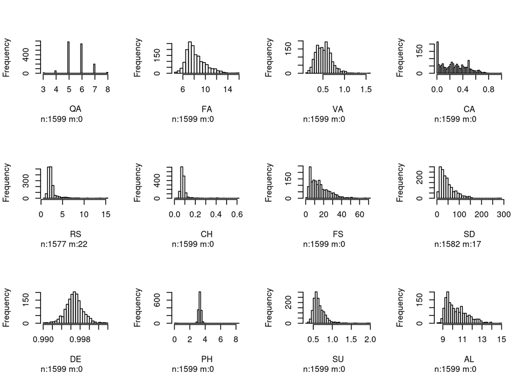

```r
hist.data.frame(data)
```

#### part b

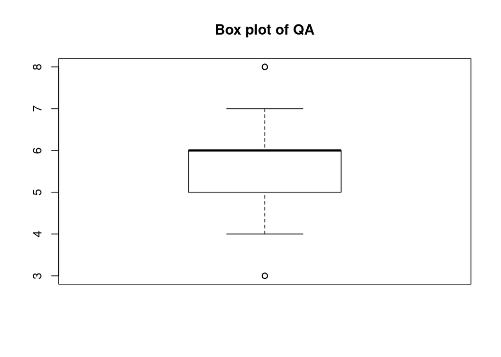

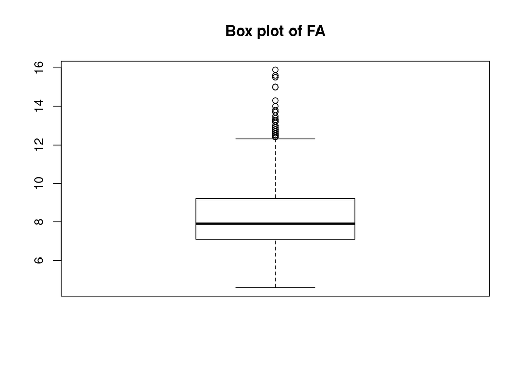

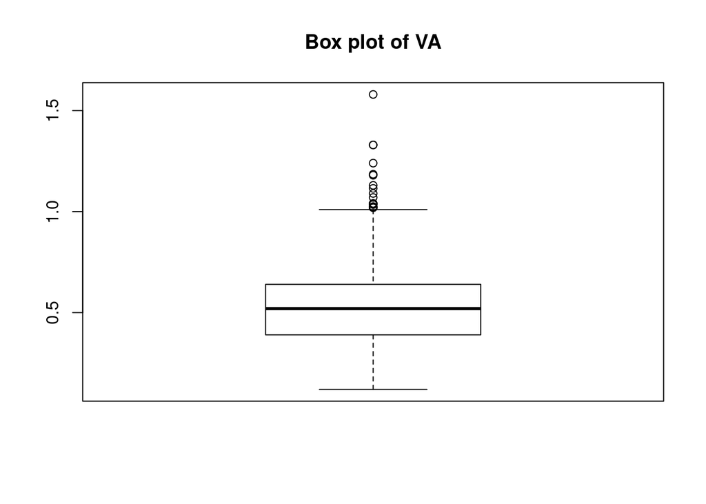

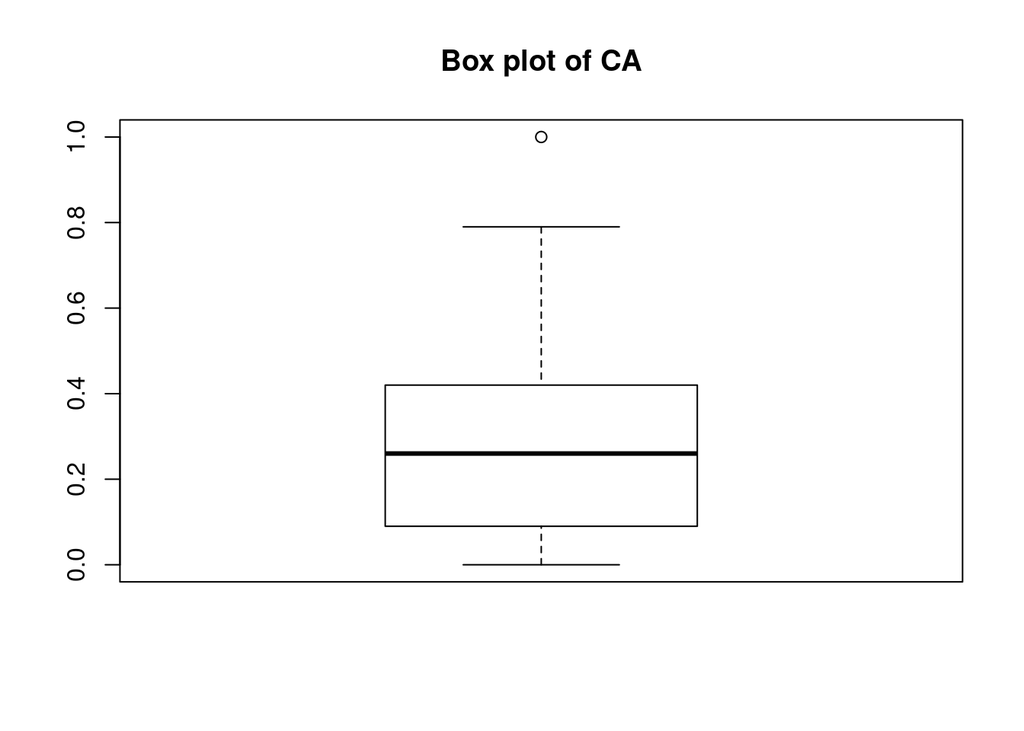

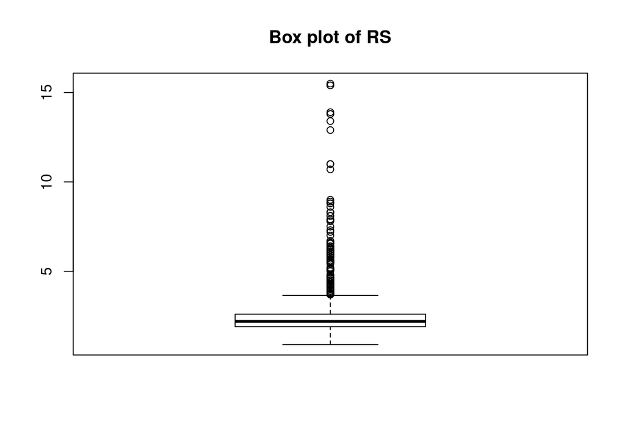

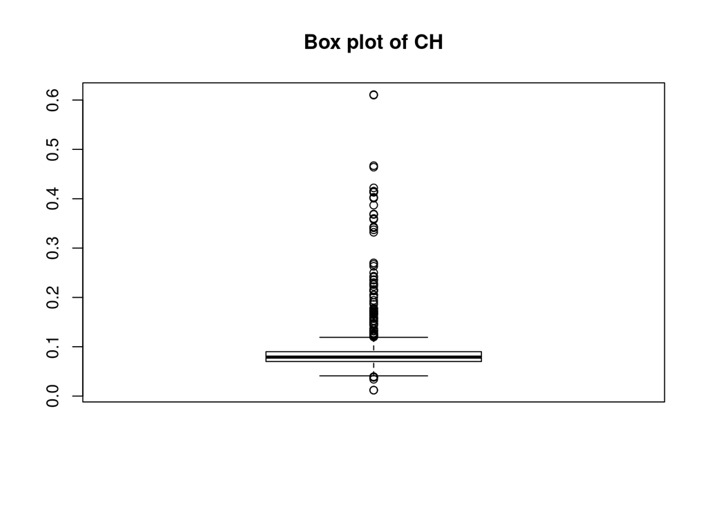

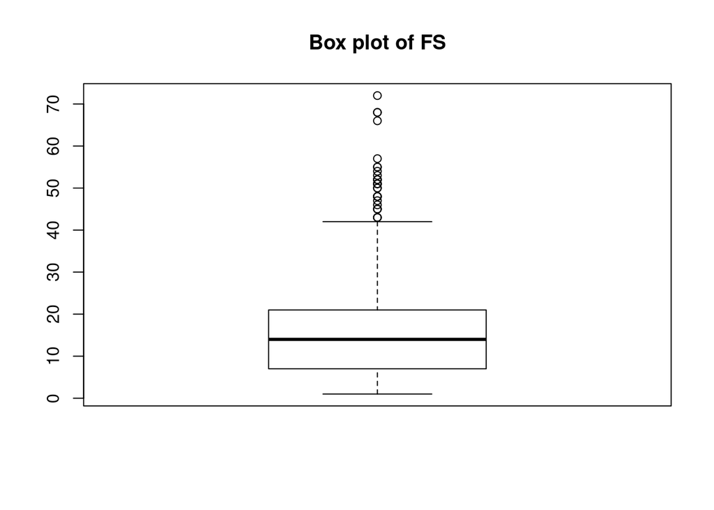

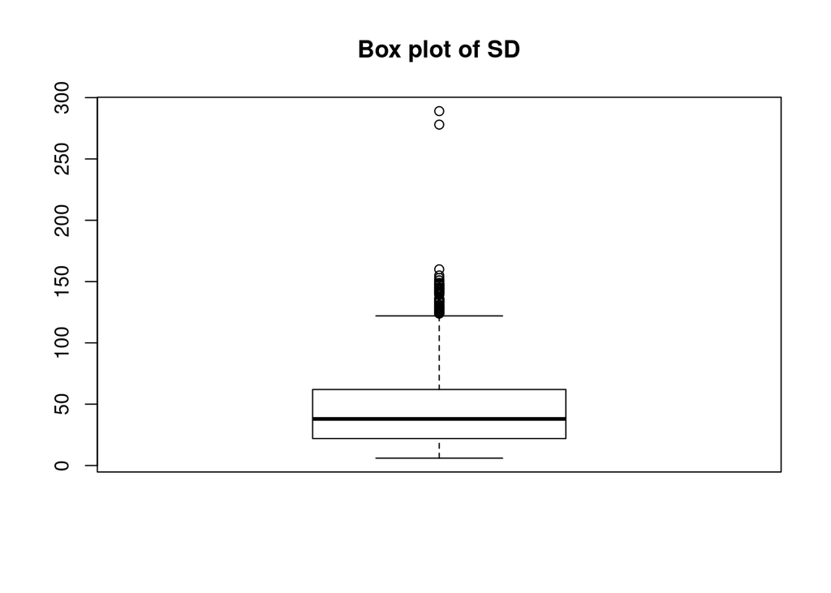

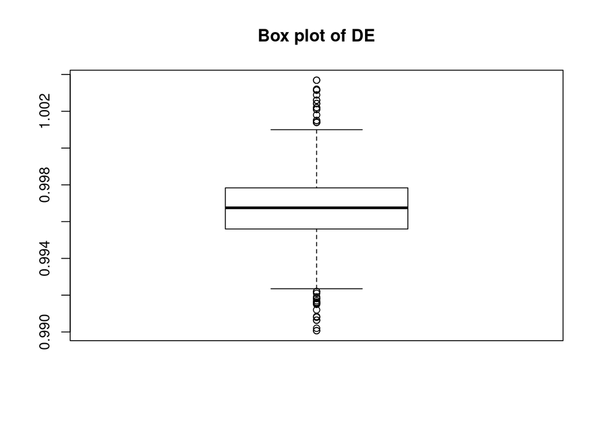

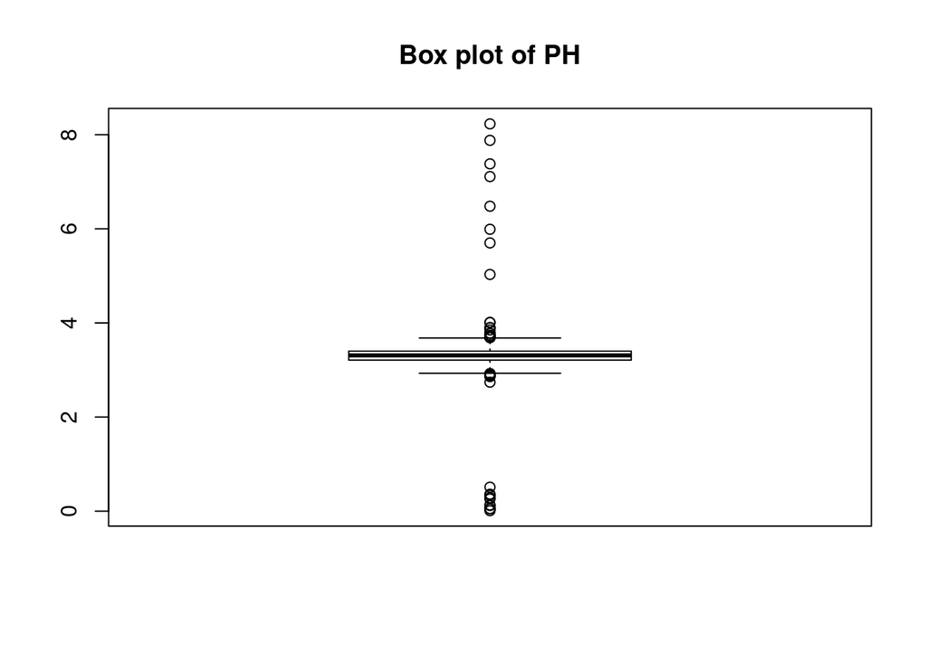

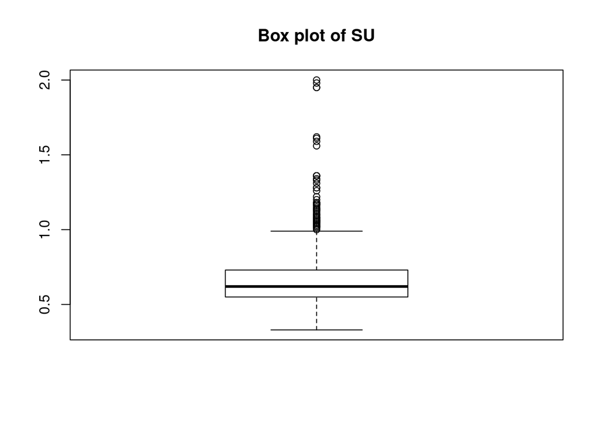

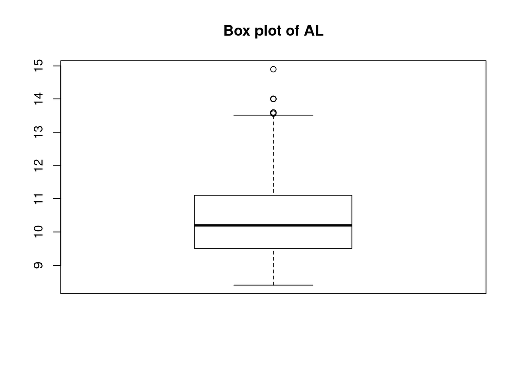

```r
for (v in names(data)){
  boxplot(data[[v]], main = paste("Box plot of", v))
}
```

SD has two siginificant outliers around 300.

PH has a handful of outliers that is below 2 or above 5.

DE has some outliers that is above around 1.002 and below 0.992.

Most of the variables have some outliers. However, it is debatable tat if those “outliers” are real outliers as some distribution is very skewed.

#### part c

```r
for (v in names(data)){
  print(paste("skewness of", v, "is", skewness(data[[v]], na.rm=T)))
  print(paste("kurtosis of", v, "is", kurtosis(data[[v]], na.rm=T)))
}
```

```
## [1] "skewness of QA is 0.217393112494184"
## [1] "kurtosis of QA is 0.287914814100104"
## [1] "skewness of FA is 0.980908398729065"
## [1] "kurtosis of FA is 1.11969865351337"
## [1] "skewness of VA is 0.670333074134222"
## [1] "kurtosis of VA is 1.2126892874226"
## [1] "skewness of CA is 0.317740288553393"
## [1] "kurtosis of CA is -0.79304552533009"
## [1] "skewness of RS is 4.53623350166493"
## [1] "kurtosis of RS is 28.4155762516905"
## [1] "skewness of CH is 5.6696937046533"
## [1] "kurtosis of CH is 41.5259634938983"
## [1] "skewness of FS is 1.24822199144251"
## [1] "kurtosis of FS is 2.00722117644335"
## [1] "skewness of SD is 1.51090324968047"
## [1] "kurtosis of SD is 3.85101264680227"
## [1] "skewness of DE is 0.0711539707521148"
## [1] "kurtosis of DE is 0.922500001404797"
## [1] "skewness of PH is 0.789389830797683"
## [1] "kurtosis of PH is 69.5155099953535"
## [1] "skewness of SU is 2.42411764489109"
## [1] "kurtosis of SU is 11.6615285220642"
## [1] "skewness of AL is 0.859214416854752"
## [1] "kurtosis of AL is 0.191658560036218"
```

**skewed left**: None.

**skewed right**: FA, VA, RS, CH, FS, SD, PH, SU, AL (skewness > 0.5)

**not significantly skewed**: QA, CA, DE (skewness < 0.5)

**leptokurtic (kurtosis > 3, fat tails)**: RS, CH, PH, SU

**platykurtic (kurtosis < 3, thin tails)**: QA, FA, VA, CA, DE, AL

#### part d

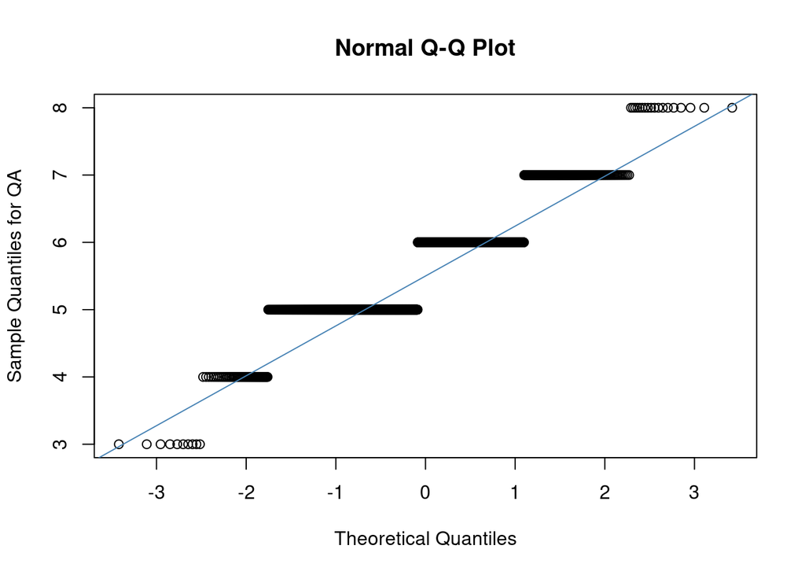

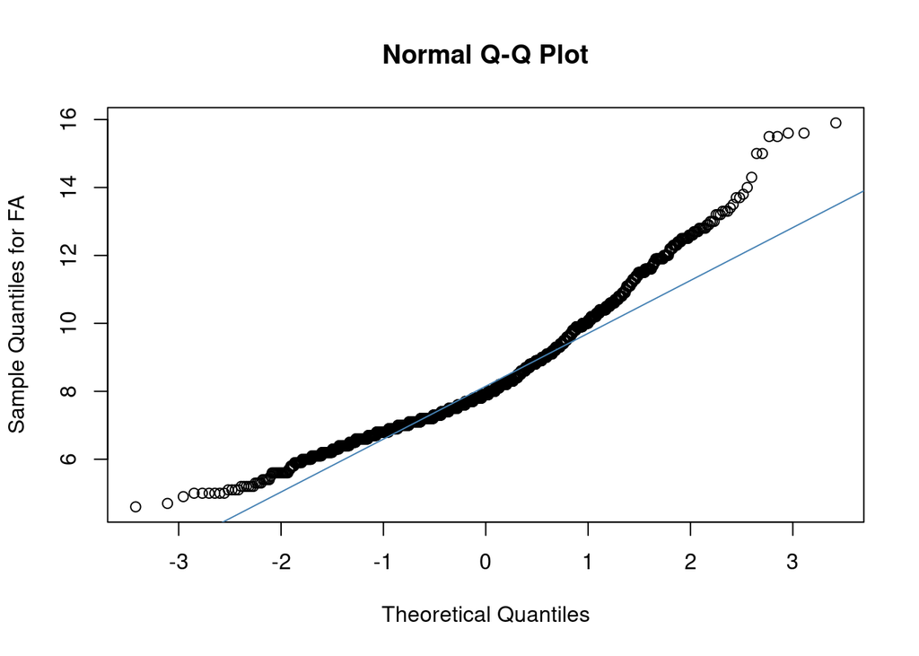

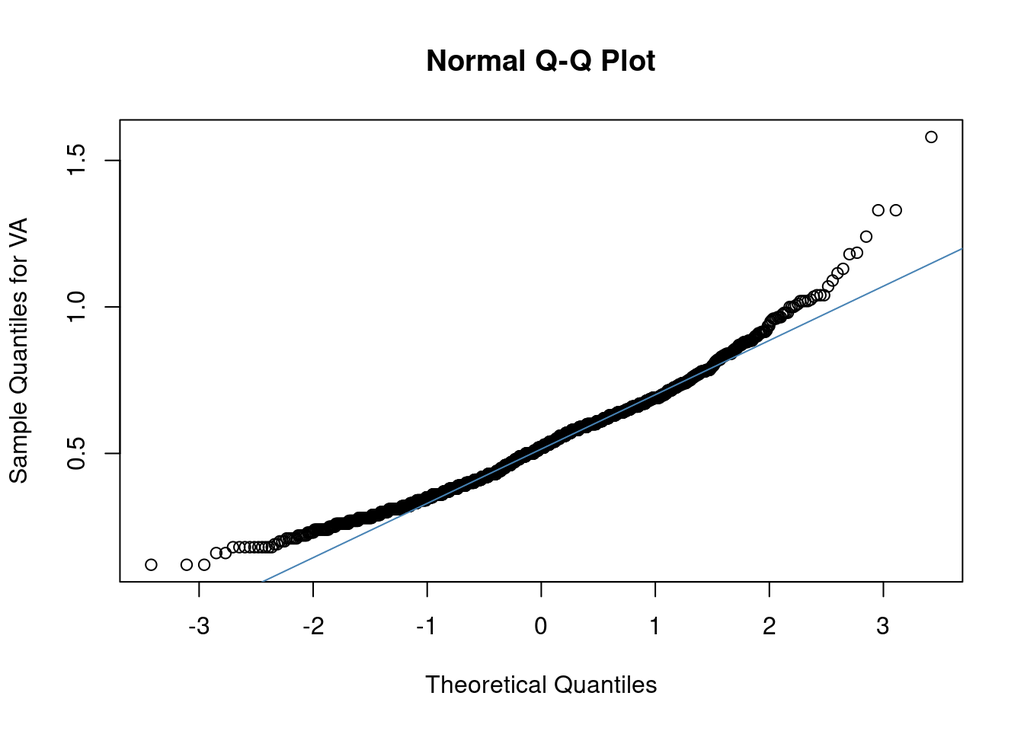

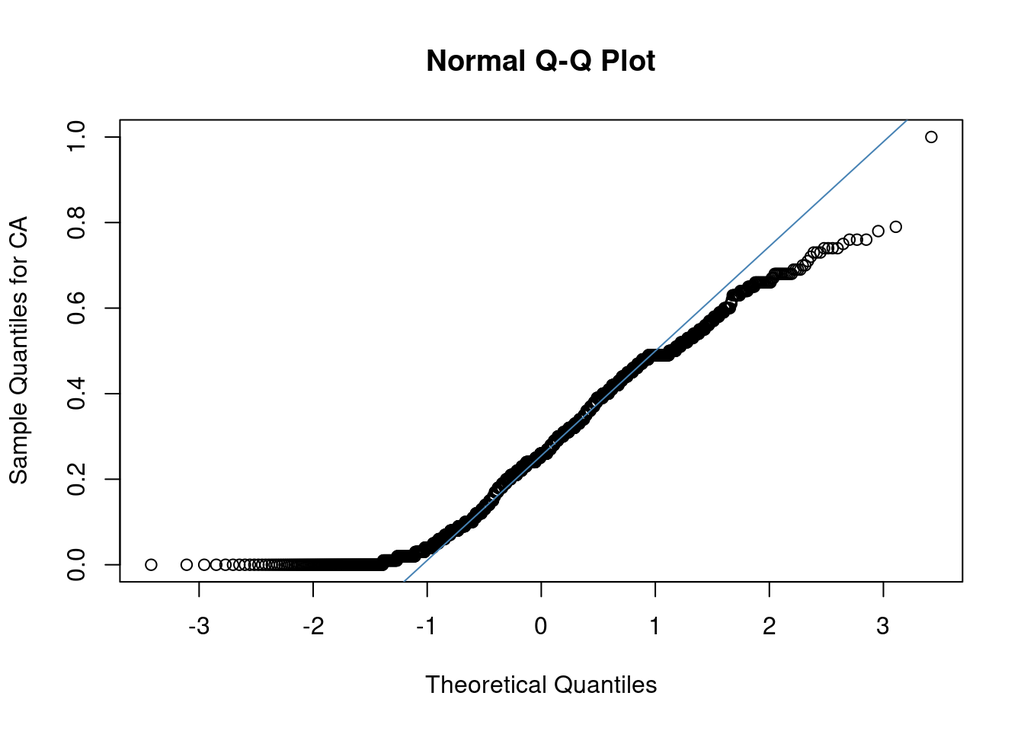

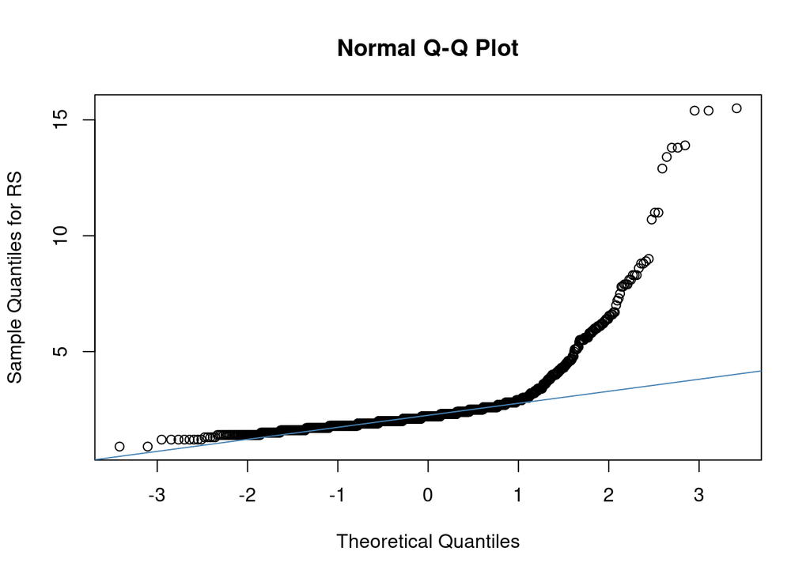

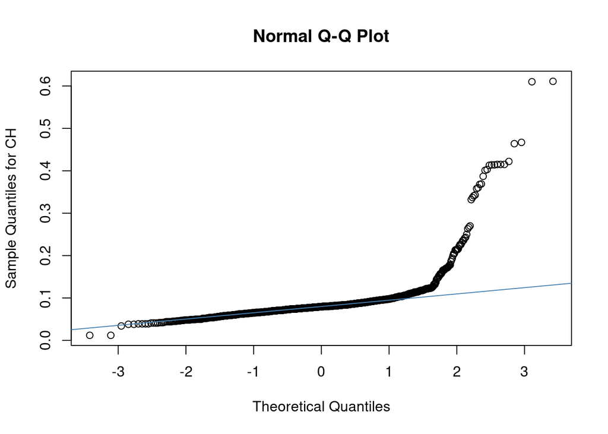

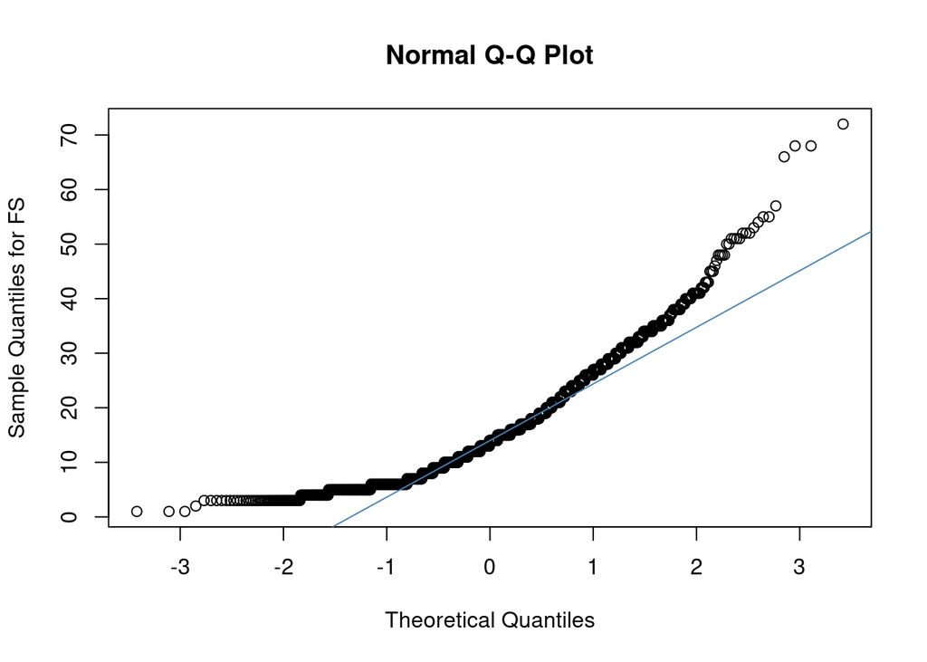

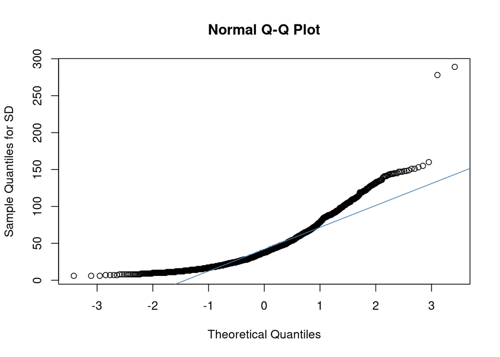

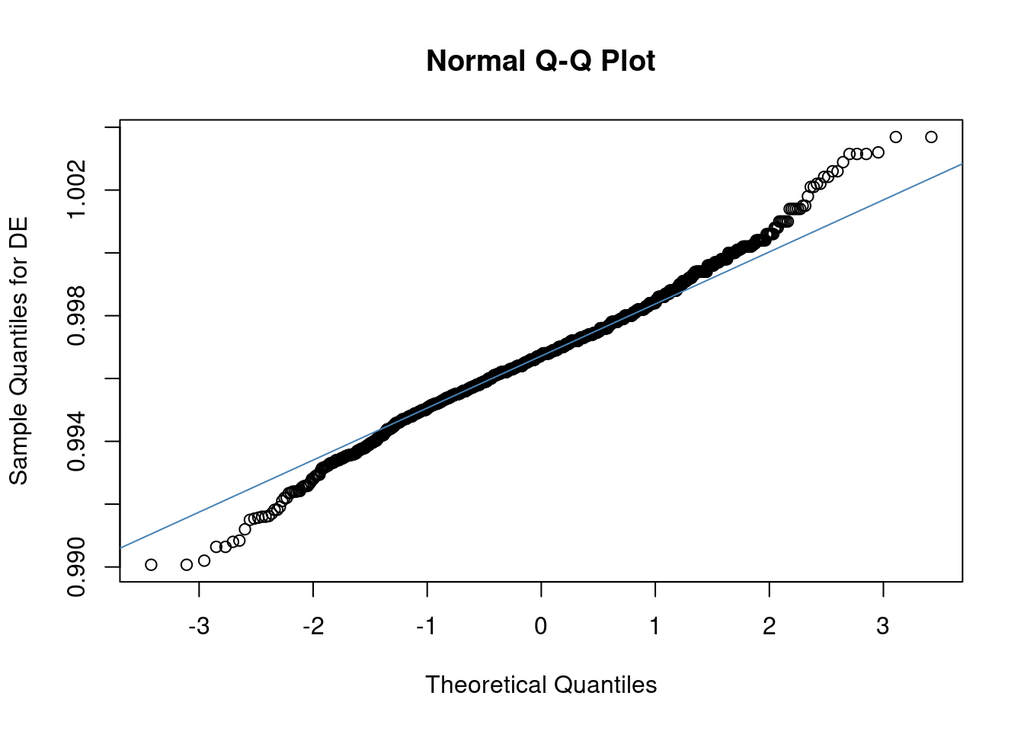

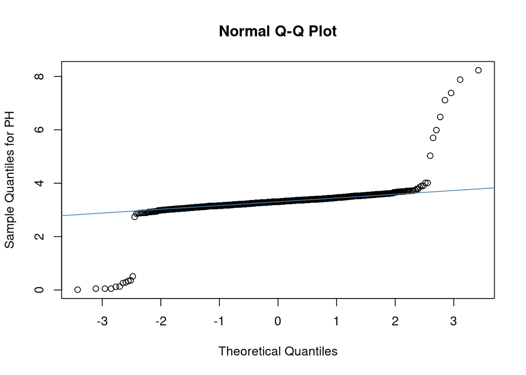

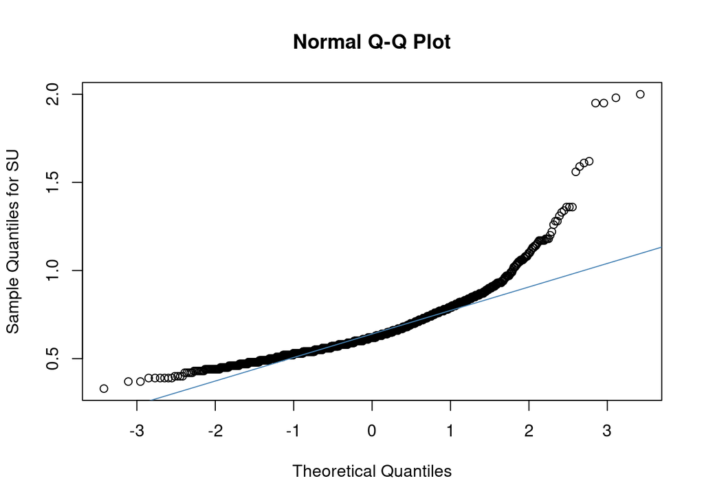

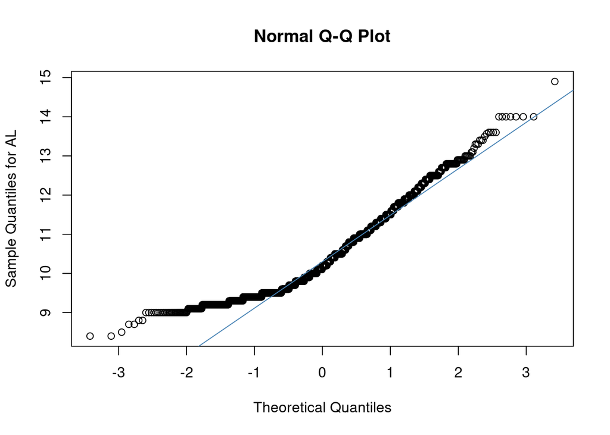

```r
for (v in names(data)){
  qqnorm(y = data[[v]], main = "Normal Q-Q Plot",
       xlab = "Theoretical Quantiles", ylab = paste("Sample Quantiles for", v),
       plot.it = TRUE, datax = FALSE)
  qqline(y = data[[v]], datax = FALSE, distribution = qnorm,
       probs = c(0.25, 0.75), qtype = 7, col = "steelblue")
}
```

The qqplots confirmed observations from previous parts.

Those variables with kurtosis > 3 also have fat tails in their qqplots.

### Problem 2

#### part a

```r
colSums(is.na(data))
```

```
## QA FA VA CA RS CH FS SD DE PH SU AL
##  0  0  0  0 22  0  0 17  0  0  0  0
```

RS and SD has missing values. There are 22 missing values in RS, and 17 missing values in SD.

```r
sum(rowSums(is.na(data)))
```

```
## [1] 39
```

There are 39 rows with missing values in total.

#### Set up cross validation folds

```r
## set up cross validation folds
set.seed(1)
n = nrow(data)
nfolds = 5
folds = createFolds(1:n, k=nfolds)
```

#### part b

```r
random.imp = function (imputeSet, sampleSet){
  missing_imputeSet = is.na(imputeSet)
  missing_sampleSet = is.na(sampleSet)
  n.missing_imputeSet = sum(missing_imputeSet) # number of missing values
  sampleSet.obs = sampleSet[!missing_sampleSet]
  imputed = imputeSet
  # sample with replacement
  imputed[missing_imputeSet] = sample(sampleSet.obs, n.missing_imputeSet, replace=T)
  return(imputed)
}
```

```r
### Linear regression and get MSE

## start a new list of the train MSEs and the test MSEs.
data = redwine
train_MSE_random = rep(NA, nfolds)
test_MSE_random = rep(NA, nfolds)

## impute
##for (i in 1:nfolds){
##  data[folds[[i]],]$SD = random.imp(data[folds[[i]],]$SD)
##  data[folds[[i]],]$RS = random.imp(data[folds[[i]],]$RS)
##}

for (i in 1:nfolds){
  train = data[-folds[[i]],]
  train$SD = random.imp(train$SD, train$SD)
  train$RS = random.imp(train$RS, train$RS)
  test = data[folds[[i]],]
  test$SD = random.imp(test$SD, train$SD)
  test$RS = random.imp(test$RS, train$RS)


  ## linear regression
  fit = lm(QA ~ ., data = train)
  train_pred = predict(fit, train)
  test_pred = predict(fit, test)

  ## MSEs
  train_MSE_random[i] = mean((train$QA - train_pred)^2)
  test_MSE_random[i] = mean((test$QA - test_pred)^2)
}
train_MSE_random
```

```
## [1] 0.4266813 0.4260077 0.4061505 0.4145461 0.4100777
```

```r
test_MSE_random
```

```
## [1] 0.3879459 0.3895373 0.4739048 0.4327250 0.4608395
```

**For random sampling imputation,**

The avg MSE on train is 0.4167 and the avg MSE on test is 0.429.

#### part c

```r
Mode = function(x) {
  mode = as.numeric(names(sort(table(x),decreasing=T))[1])
  return(mode)
}

mcv.imp = function (imputeSet, sampleSet){
  missing_imputeSet = is.na(imputeSet)
  imputed = imputeSet
  imputed[missing_imputeSet] = Mode(sampleSet)
  return(imputed)
}
```

```r
### Linear regression and get MSE

## start a new list of the train MSEs and the test MSEs.
data = redwine
train_MSE_mode = rep(NA, nfolds)
test_MSE_mode = rep(NA, nfolds)

## impute
##for (i in 1:nfolds){
##  data[folds[[i]],]$SD = mcv.imp(data[folds[[i]],]$SD)
##  data[folds[[i]],]$RS = mcv.imp(data[folds[[i]],]$RS)
##}

for (i in 1:nfolds){
  train = data[-folds[[i]],]
  test = data[folds[[i]],]
  train$SD = mcv.imp(train$SD, train$SD)
  train$RS = mcv.imp(train$RS, train$RS)
  test$SD = mcv.imp(test$SD, train$SD)
  test$RS = mcv.imp(test$RS, train$RS)


  ## linear regression
  fit = lm(QA ~ ., data = train)
  train_pred = predict(fit, train)
  test_pred = predict(fit, test)

  ## MSEs
  train_MSE_mode[i] = mean((train$QA - train_pred)^2)
  test_MSE_mode[i] = mean((test$QA - test_pred)^2)
}
train_MSE_mode
```

```
## [1] 0.4265044 0.4258749 0.4059704 0.4155705 0.4102859
```

```r
test_MSE_mode
```

```
## [1] 0.3866048 0.3892670 0.4736698 0.4335167 0.4604219
```

**For mode imputation,**

The avg MSE on train is 0.4168 and the avg MSE on test is 0.4287.

#### part d

```r
avg.imp = function (imputeSet, sampleSet){
  missing_imputeSet = is.na(imputeSet)
  imputed = imputeSet
  imputed[missing_imputeSet] = mean(sampleSet, na.rm=T)
  return(imputed)
}
```

```r
### Linear regression and get MSE

## start a new list of the train MSEs and the test MSEs.
data = redwine
train_MSE_avg = rep(NA, nfolds)
test_MSE_avg = rep(NA, nfolds)

## impute
##for (i in 1:nfolds){
##  data[folds[[i]],]$SD = avg.imp(data[folds[[i]],]$SD)
##  data[folds[[i]],]$RS = avg.imp(data[folds[[i]],]$RS)
## }

for (i in 1:nfolds){
  train = data[-folds[[i]],]
  test = data[folds[[i]],]
  train$SD = avg.imp(train$SD, train$SD)
  train$RS = avg.imp(train$RS, train$RS)
  test$SD = avg.imp(test$SD, train$SD)
  test$RS = avg.imp(test$RS, train$RS)

  ## linear regression
  fit = lm(QA ~ ., data = train)
  train_pred = predict(fit, train)
  test_pred = predict(fit, test)

  ## MSEs
  train_MSE_avg[i] = mean((train$QA - train_pred)^2)
  test_MSE_avg[i] = mean((test$QA - test_pred)^2)
}
train_MSE_avg
```

```
## [1] 0.4265376 0.4257172 0.4057926 0.4154515 0.4100624
```

```r
test_MSE_avg
```

```
## [1] 0.3859994 0.3893899 0.4739150 0.4334546 0.4603702
```

**For mean imputation,**

The avg MSE on train is 0.4167 and the avg MSE on test is 0.4286.

#### part e

```r
## 5NN

## start a new list of the train MSEs and the test MSEs.
data = redwine
train_MSE_5NN = rep(NA, nfolds)
test_MSE_5NN = rep(NA, nfolds)

## impute
##for (i in 1:nfolds){
##  data[folds[[i]],] = knnImputation(data[folds[[i]],], k=5, distData =)
##}

for (i in 1:nfolds){
  train = data[-folds[[i]],]
  test = data[folds[[i]],]
  train = knnImputation(train, k=5, distData = train)
  test = knnImputation(test, k=5, distData = train)

  ## linear regression
  fit = lm(QA ~ ., data = train)
  train_pred = predict(fit, train)
  test_pred = predict(fit, test)

  ## MSEs
  train_MSE_5NN[i] = mean((train$QA - train_pred)^2)
  test_MSE_5NN[i] = mean((test$QA - test_pred)^2)
}
train_MSE_5NN
```

```
## [1] 0.4266756 0.4258326 0.4053918 0.4153177 0.4100196
```

```r
test_MSE_5NN
```

```
## [1] 0.3852174 0.3887902 0.4748452 0.4331348 0.4603574
```

**For 5NN imputation,**

The avg MSE on train is 0.4166 and the avg MSE on test is 0.4285.

#### part f

```r
## MICE
## start a new list of the train MSEs and the test MSEs.
data = redwine
train_MSE_mice = rep(NA, nfolds)
test_MSE_mice = rep(NA, nfolds)


for (i in 1:nfolds){
  train = data[-folds[[i]],]
  train$t = FALSE
  test = data[folds[[i]],]
  test$t = TRUE
  d = rbind(train, test)
  imputed =  mice(d, m = 10, seed = 1, defaultMethod = 'pmm', print = F, ignore = d$t)
  d = complete(imputed, 5)
  train = d[d$t == FALSE, ]
  test = d[d$t == TRUE,]
  drops <- c("t")
  train = train[ , !(names(d) %in% drops)]
  test = test[ , !(names(d) %in% drops)]

  ## linear regression
  fit = lm(QA ~ ., data = train)
  train_pred = predict(fit, train)
  test_pred = predict(fit, test)

  ## MSEs
  train_MSE_mice[i] = mean((train$QA - train_pred)^2)
  test_MSE_mice[i] = mean((test$QA - test_pred)^2)
}
train_MSE_mice
```

```
## [1] 0.4267367 0.4255685 0.4065194 0.4160206 0.4103638
```

```r
test_MSE_mice
```

```
## [1] 0.3849609 0.3891596 0.4757336 0.4334009 0.4598720
```

**For MICE imputation,**

The avg MSE on train is 0.417 and the avg MSE on test is 0.4286.

#### part g

```r
## dropna

## start a new list of the train MSEs and the test MSEs.
data = redwine
train_MSE_del = rep(NA, nfolds)
test_MSE_del = rep(NA, nfolds)


for (i in 1:nfolds){
  train = data[-folds[[i]],] %>% na.omit()
  test = data[folds[[i]],]  %>% na.omit()


  ## linear regression
  fit = lm(QA ~ ., data = train)
  train_pred = predict(fit, train)
  test_pred = predict(fit, test)

  ## MSEs
  train_MSE_del[i] = mean((train$QA - train_pred)^2)
  test_MSE_del[i] = mean((test$QA - test_pred)^2)
}
train_MSE_del
```

```
## [1] 0.4299961 0.4292546 0.4074342 0.4185579 0.4125802
```

```r
test_MSE_del
```

```
## [1] 0.3865348 0.3887269 0.4818940 0.4352727 0.4633072
```

**For drop NA,**

The avg MSE on train is 0.4196 and the avg MSE on test is 0.4311.

#### part h

**random:**

The avg MSE on train is 0.4166927 and the avg MSE on test is 0.4289905.

**mode:**

The avg MSE on train is 0.4168412 and the avg MSE on test is 0.428696.

**mean:**

The avg MSE on train is 0.4167123 and the avg MSE on test is 0.4286258.

**5NN:**

The avg MSE on train is 0.4166475 and the avg MSE on test is 0.428469.

**MICE:**

The avg MSE on train is 0.4170418 and the avg MSE on test is 0.4286254.

**drop:**

The avg MSE on train is 0.4195646 and the avg MSE on test is 0.4311471.

*All of the MSEs are similar. So I personally don’t think one is doing a significantly better job than the others.*

**The lowest MSE for both train and test sets is with 5NN.**

5NN is slightly better (maybe) because it look at the nearest neighbors. It determine the imputed value within a reasonable range.